# Setting up your cuts

## Cutting principles

1. Cut with a **purpose**, not just to get the disc. This purpose should reflect the spaces on the pitch that you are trying to attack:
- To score
- To gain yards
- To get the disc to the breakside
- To get the disc off the sideline
- To get the disc in power position
- To clear space for other cutters
2. Keep the **throwing lane clear**. This makes the throwers job a lot easier.
- You are not the only option on the field
- Keep defenders out of the open throwing space
- Cut across the throwing lane rather than in it.
3. Be **predictable**.
- The thrower needs to predict where you are running to
- Long purposeful cuts and hard sharp turns
- Communicate with the thrower (eyes up, hands up etc.)
4. Gain **separation** from your defender.
- Run faster
- Turn faster
- Create moments of decision for your defender (what does this mean?)

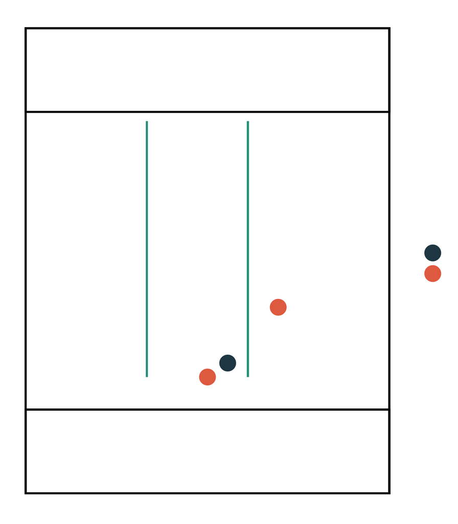

## Basic upfield cutting patterns

- Go straight deep and wide of the lane
- Cut under on an angle and cross the throwing lane
- Use lateral cuts to get to break side or power positions

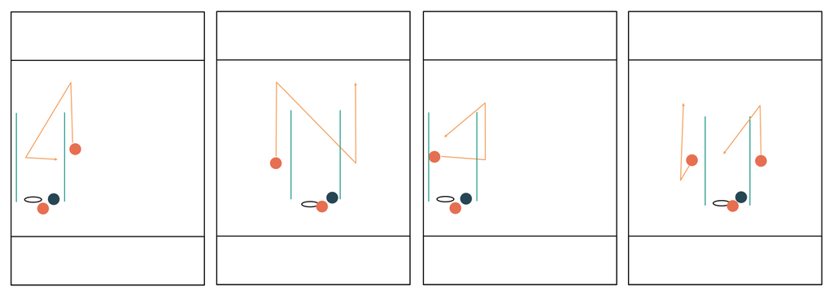

## Setting up your cut

Setting up your cut means getting some **initial separation** from your defender and giving yourself an **angle** to purposefully attack space on the field.

When do I need to do this?

- Starting stationary from a dead disc or before initiation
- Continuation cuts from the far side of the field
- Starting from a very shallow position or already in the lane
- Your defender is very good

How do I do this?

- Use space outside of the throwing lane to set up your cut
- Take your defender to decision points
- Move your defender
  - Sharp turn
  - Change of pace
  - Fake / side step / jink
  - Get them to back pedal by running at them
  - Force them to turn their hips

## What is a decision point?

A decision point is an area on the field where are a threat in multiple directions and your defender must choose to take one of these away or try to mark all of them.

- A: The deep cut is not a threat as the defender will have time to catch up, so they can sit underneath.
- B: The in cut is not a threat as minimal yards are on offer under pressure.
- C: Attacking the decision point means you are in a position to be hit deep and also gain a lot of yards underneath. The defender must choose to take one option away…
- D: Or get closer to you and try to take away both.

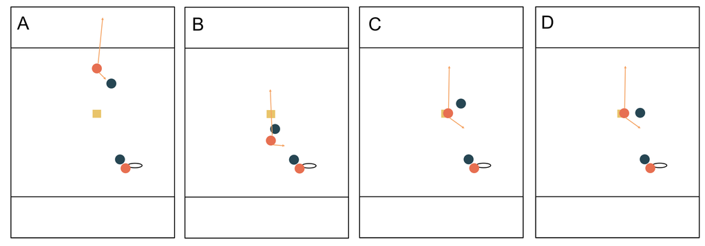

Here is a classic example from a continuation cutter coming from the far side of the field. He attacks a decision point where he is a threat going to the endzone and also coming under (the defender is clearly more worried about the deep). He performs a couple of side steps to create extra separation and ends up with an easy in cut to the open side.

[video not shown]

Note that all of this is performed wide of the throwing lane and he makes it clear to the thrower when he is committing to a cut by getting his head up and making eye contact.

## More upfield cutting examples

This example comes from an isolated initiation cutter. They setup in a position where they are marked deep but the break side is also a threat. By moving towards the break side they force the defender to follow and commit their momentum towards the disc to close down the cut. Because the cutter initially moves laterally they only need to turn 90 degrees to go deep, whereas the defender has to turn nearly 180 degrees as they are closing in from deep. In all of these clips it’s worth slowing down to find the frame where the offense player’s hips are pointing where they want to go and the defender’s are in the opposite direction (use the . and , keys for frame progression).

[video not shown]

Similarly in this example the cutter uses the lateral cut to great effect. He has no right to get free deep from his original position but he draws the defender in and changes direction while the defender is moving in the opposite direction from where he wants to go.

[video not shown]

## Lateral movement

Using a lateral movement to set up your cut is a great way to shift your defenders momentum. Most of the time a defender will set up to defend cuts towards the endzone and towards the disc on the open side. They will position their body in one of these lanes and face the other so they are ready to attack. Moving laterally forces them to adjust their position as your angle to the disc changes. This movement can get them to back pedal or commit their hips to moving in a straight line.

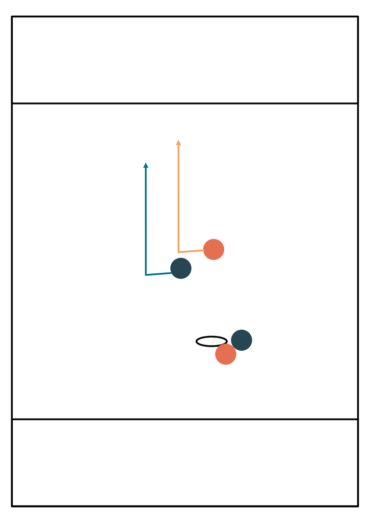

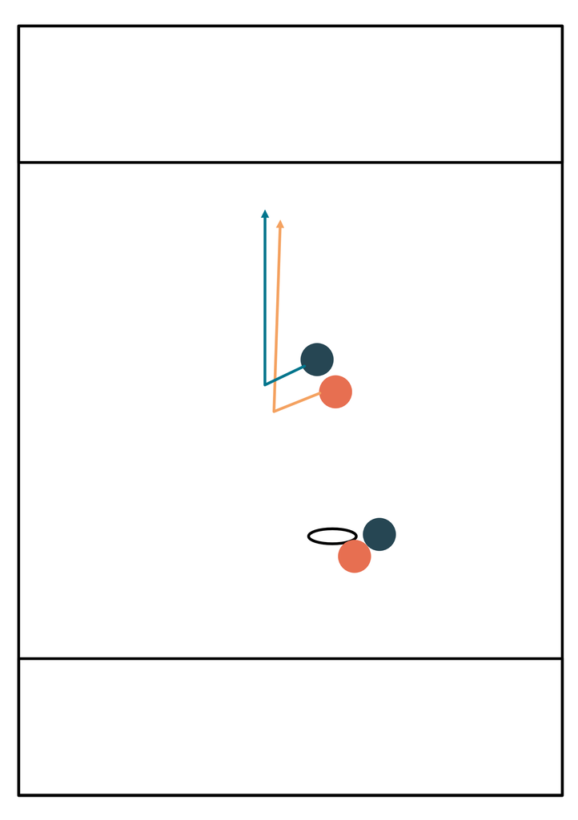

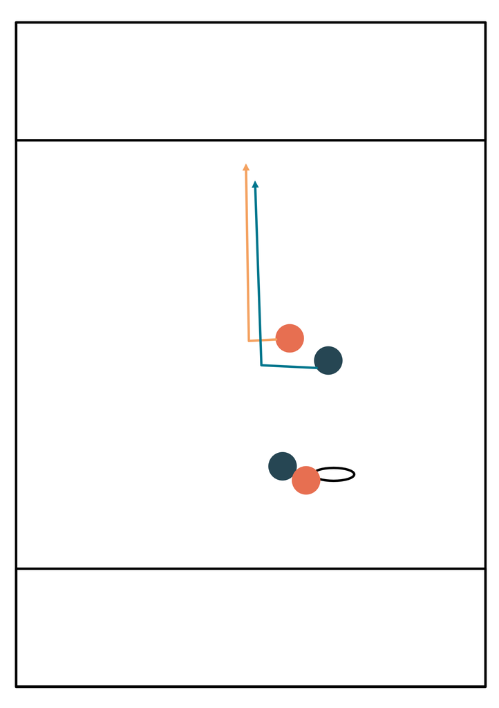

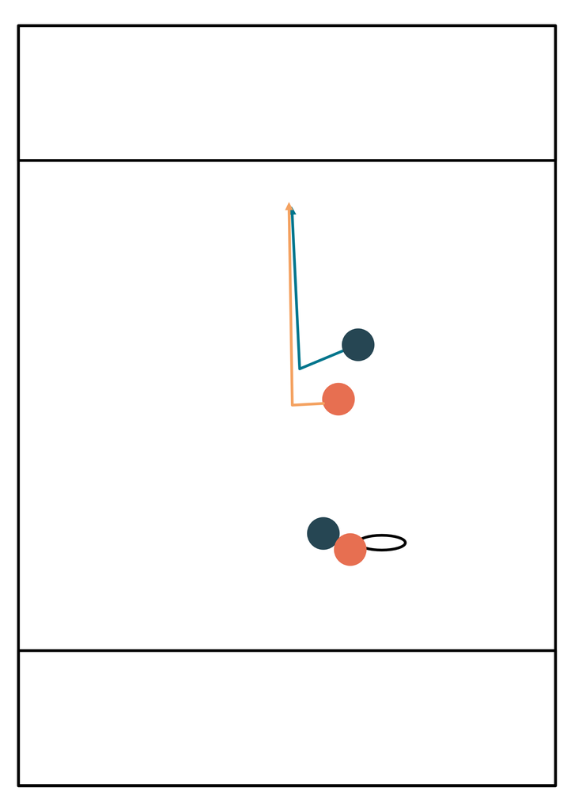

## What about handler cuts?

Handlers can use decision points as well. A defender is normally wary of being beaten up the line or for a swing pass. Take your defender to a point where you are a genuine threat for both.

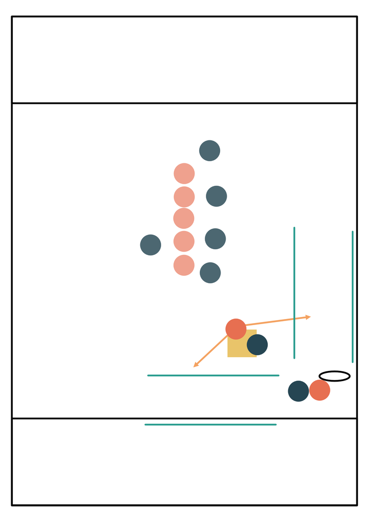

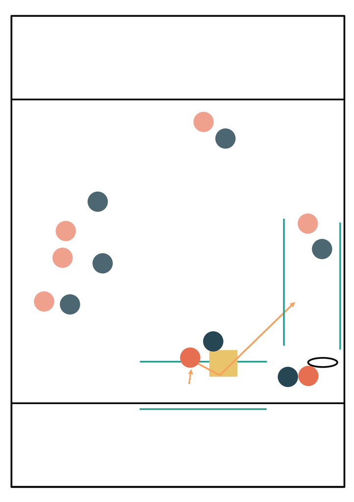

Here is a good illustration of the second example. The reset pushes upfield. Their initial movement is towards the defender to get them on their heels. He then makes a movement towards the swing lane which forces the defender to bite and open his hips. This creates room to drive inside with a drop step, get around the defender and get separation going up the line.

[video not shown]

## Summary

- Set up your cut outside of the throwing lane, keep the lanes free for your commited purposeful cuts
- Force your defender to make decisions
- Get your defender off balance or use their momentum against them
- Go out and practice your footwork and cutting patterns!!!